# Cross-validation

2025-06-11

# Libraries

```r
knitr::opts_chunk$set(echo = T, warning = FALSE, message = FALSE)
suppressMessages(suppressWarnings(source('0.libraries.R')))
suppressMessages(suppressWarnings(source('0.test_signature_on_dataset_PP.R')))
```

# Associate patients to communities

```r
fold_comm <- list.files('../Step4/output_communities/')
comm_pat <- list()
for(i_fold in 1:7){
  comm_pat[[i_fold]] <- read_tsv(paste0('../Step4/Communities/output_communities/community_',
                                        i_fold, '/patients.txt'), col_names = 'patient_id') %>% pull(patient_id)
}

names(comm_pat) <- paste0('CL', 1:7)
```

# Prepare crossvalidation input

The generated data and results for the following analyses cannot be stored on github due to size limits. To obtain the data, feel free to contact us at veronica.lombardi@uniroma1.it and livia.perfetto@uniroma1.it.

```r
for (i in 1:50) {
  message("Processing iteration ", i)
  all_patients_train <- c()
  all_patients_test <- c()

  for (comm_name in names(comm_pat)) {
    patients <- comm_pat[[comm_name]]
    n <- length(patients)
    n_train <- floor(0.7 * n)

    # Sample training and test sets
    train_patients <- sample(patients, n_train)
    test_patients <- setdiff(patients, train_patients)
    all_patients_train <- c(all_patients_train, train_patients)
    all_patients_test <- c(all_patients_test, train_patients)

    # Create output folders
    train_dir <- file.path(paste0("Crossvalidation_input/output_communities_train_", i), comm_name)
    test_dir  <- file.path(paste0("Crossvalidation_input/output_communities_test_", i), comm_name)

    dir.create(train_dir, recursive = TRUE, showWarnings = FALSE)
    dir.create(test_dir, recursive = TRUE, showWarnings = FALSE)

    # Write to file
    writeLines(train_patients, file.path(train_dir, "patients.txt"))
    writeLines(test_patients, file.path(test_dir, "patients.txt"))
  }

  tr_df <- read_tsv("../Step5/Transcriptomics_updated_CPTAC_coding.tsv")
  tr_df_train <- tr_df %>% select(gene_name, all_patients_train)
  tr_df_test <- tr_df %>% select(gene_name, all_patients_test)
  write_tsv(tr_df_train, paste0('Transcriptomics_data_train_test/Train_CPTAC_coding_', i, '.tsv'))
  write_tsv(tr_df_test, paste0('Transcriptomics_data_train_test/Test_CPTAC_coding_', i, '.tsv'))
}
```

# Run crossvalidation

## I) Extract signatures from patients subsets

```r
library(future.apply)
plan(multisession, workers = 10)

future_lapply(1:50, function(i) {

  source('./0.libraries.R')

  message("Running iteration ", i)

  #Run for communities 2, 3,4 , 7
  extract_signatures(base_path = paste0("./Crossvalidation_input/output_communities_train_", i, "/"),
                     transcriptomics_file =  paste0('Transcriptomics_data_train_test/Train_CPTAC_coding_', i, '.tsv'),
                     output_dir = paste0("./Crossvalidation_signatures/Run_for_communities_2_3_4_7_training_", i),
                     diff_thres = 0.7)

  #Run for communities 1, 5, 6
  extract_signatures(base_path =  paste0("./Crossvalidation_input/output_communities_train_", i, "/"),
                     transcriptomics_file = paste0('Transcriptomics_data_train_test/Train_CPTAC_coding_', i, '.tsv'),
                     output_dir = paste0("./Crossvalidation_signatures//Run_for_communities_1_5_6_training_", i),
                     diff_thres = 0.5)

  return(NULL)
})
```

Combine the signatures in a single folder.

```r
for(i in c(1:50)){
  # Define source directories
  parent_dir_1 <- paste0("./Crossvalidation_signatures/Run_for_communities_1_5_6_training_", i)
  parent_dir_2 <- paste0("./Crossvalidation_signatures/Run_for_communities_2_3_4_7_training_", i)

  dir_1 <- file.path(parent_dir_1, "Signatures")
  dir_2 <- file.path(parent_dir_2, "Signatures")

  # Define the files to extract
  files_1 <- c("signature_community_1.tsv", "signature_community_5.tsv", "signature_community_6.tsv")
  files_2 <- c("signature_community_2.tsv", "signature_community_3.tsv", "signature_community_4.tsv", "signature_community_7.tsv")

  # Define the destination directory
  dest_dir <- paste0("./Crossvalidation_signatures/Run_for_communities_training_", i)
  dir.create(dest_dir)

  # Function to move files
  move_files <- function(file_list, source_dir, destination_dir) {
    for (file in file_list) {
      source_path <- file.path(source_dir, file)
      dest_path <- file.path(destination_dir, file)

      # Check if the file exists before moving
      if (file_exists(source_path)) {
        file_move(source_path, dest_path)
        cat("Moved:", file, "to", destination_dir, "\n")
      } else {
        cat("File not found:", file, "\n")
      }
    }
  }

  # Move the required files
  move_files(files_1, dir_1, dest_dir)
  move_files(files_2, dir_2, dest_dir)

  # Delete the directories, including their parent folders
  if (dir_exists(parent_dir_1)) {
    dir_delete(parent_dir_1)
    cat("Deleted directory:", parent_dir_1, "\n")
  }
  if (dir_exists(parent_dir_2)) {
    dir_delete(parent_dir_2)
    cat("Deleted directory:", parent_dir_2, "\n")
  }
}
```

## II) Run FGSEA analysis on CPTAC validation data

```r
source('0.run_fgsea_signatures.R')

library(future)
library(future.apply)
library(readr)

# Set up parallel plan (adjust depending on your system: multisession for Windows, multicore for Unix-like)
#plan(multisession)  # or plan(multicore) on Linux/macOS
plan(multisession, workers = 10)

# Define the function to apply in parallel
run_analysis <- function(i_run) {
  dest_dir <- paste0("./Crossvalidation_signatures/Run_for_communities_training_", i_run)

  n_com <- list.files(dest_dir)

  gene_signatures <- list()
  for (i in seq_along(n_com)) {
    comm_f <- read_tsv(paste0(dest_dir, '/signature_community_', i, '.tsv'), show_col_types = FALSE)
    gene_signatures[[i]] <- comm_f$gene_name
  }
  names(gene_signatures) <- paste0("Comm_", seq_along(n_com))

  transcriptomics_data <- read_tsv(paste0('Transcriptomics_data_train_test/Test_CPTAC_coding_', i_run, '.tsv'))

  enrichment_result <- tryCatch(
    {
      run_fgsea_signatures(
        gene_signatures = gene_signatures,
        transcriptomic_data = transcriptomics_data,
        pval_cutoff = 0.05,
        NES_filter = TRUE
      )
    },
    error = function(e) {
      message("Error in run ", i_run, ": ", e$message)
      return(NULL)
    }
  )

  if (!is.null(KM_list)) {
    write_tsv(enrichment_result, paste0('./BRCA_enrichment_test/fgsea_cptac_test_', i_run, '.tsv'))
  }

  return(NULL)  # return nothing or custom status
}

# Run in parallel over 1:50
future_lapply(1:50, run_analysis)
```

# Compute key metrics

## Precision, Recall and F1 score

```r
# Get true labels once (assuming static across runs)
com_TP <- stack(comm_pat)
colnames(com_TP) <- c("patient_id", "community")

# Initialize list to collect metrics
all_metrics <- list()

for (i_run in 1:50) {

  # Read enrichment and transcriptomics data
  enrichment_df <- read_tsv(paste0("./BRCA_enrichment_test/fgsea_cptac_test_", i_run, ".tsv"), show_col_types = FALSE)
  transcriptomics_data <- read_tsv(paste0('Transcriptomics_data_train_test/Test_CPTAC_coding_', i_run, '.tsv'),
                                   show_col_types = FALSE)
  test_patients <- colnames(transcriptomics_data)[-1]

  # Infer community label from enrichment
  sign_pats <- enrichment_df %>%
    filter(NES > 0) %>%
    group_by(patient_id) %>%
    slice_min(order_by = padj, n = 1) %>%
    slice_max(order_by = NES, n = 1) %>%
    ungroup() %>%
    filter(padj < 0.01) %>%
    dplyr::rename('inferred_label' = 'pathway') %>%
    mutate(inferred_label = str_replace(inferred_label, "^Comm_(\\d+)$", "CL\\1"))

  # Join true and inferred labels
  com_TP_inf <- full_join(sign_pats, com_TP, by = 'patient_id') %>%
    filter(patient_id %in% test_patients)

  # Compute metrics
  metrics <- com_TP_inf %>%
    dplyr::group_by(community) %>%
    dplyr::summarise(
      TP = sum(community == inferred_label, na.rm = TRUE),
      FN = sum(is.na(inferred_label) & !is.na(community)),
      FP = sum(community != inferred_label, na.rm = TRUE),
      Precision = ifelse((TP + FP) > 0, TP / (TP + FP), NA),
      Recall = ifelse((TP + FN) > 0, TP / (TP + FN), NA),
      F1 = ifelse(!is.na(Precision) & !is.na(Recall) & (Precision + Recall) > 0,
                   2 * Precision * Recall / (Precision + Recall), NA),
      .groups = "drop"
    ) %>%
    mutate(run = i_run)

  # Store results
  all_metrics[[i_run]] <- metrics
}

# Combine all metrics into one dataframe
final_metrics<- bind_rows(all_metrics)

write_tsv(final_metrics, './results/crossvalidation_f1_score.tsv')
```

## Patient community size and signatures’ size

### Patients’ number

```r
for (i in 1:50) {
  # Create output folders
  train_dir <- file.path(paste0("Crossvalidation_input/output_communities_train_", i))
  test_dir  <- file.path(paste0("Crossvalidation_input/output_communities_test_", i))

  #i_comm = 1
  for(i_comm in c(1:7)){
    comm_pat <- read_tsv(paste0(train_dir, '/community_', i_comm, '/patients.txt'), col_names = c('patient_id'))
    comm_pat$community <- paste0('CL', i_comm)
    comm_pat$run <- paste0('run_', i)
    comm_pat$group <- 'train'

    comm_pat_t <- read_tsv(paste0(test_dir, '/community_', i_comm, '/patients.txt'), col_names = c('patient_id'))
    comm_pat_t$community <- paste0('CL', i_comm)
    comm_pat_t$run <- paste0('run_', i)
    comm_pat_t$group <- 'test'

    comm_pat_i <- bind_rows(comm_pat, comm_pat_t)
    if(i == 1 & i_comm == 1){
      comm_pat_all <- comm_pat_i
    }else{
      comm_pat_all <- bind_rows(comm_pat_all, comm_pat_i)
    }
  }
}

write_tsv(comm_pat_all, './results/crossvalidation_patients_dim.tsv')
```

### Signatures’ size

```r
for (i_run in 1:50) {
  #i_run = 1
  dest_dir <- paste0("./Crossvalidation_signatures/Run_for_communities_training_", i_run)

  n_com <- list.files(dest_dir)
  gene_signatures <- list()
  for (i in seq_along(n_com)) {
    comm_f <- read_tsv(paste0(dest_dir, '/signature_community_', i, '.tsv'), show_col_types = FALSE)
    gene_signatures[[i]] <- comm_f$gene_name
  }
  names(gene_signatures) <- paste0("CL", seq_along(n_com))

  gene_signatures_df <- stack(gene_signatures)
  gene_signatures_df$run <- paste0('run_', i_run)
  if(i_run == 1){
    gene_signatures_df_all <- gene_signatures_df
  }else{
    gene_signatures_df_all <- bind_rows(gene_signatures_df_all, gene_signatures_df)
  }
}

gene_signatures_df_all %>%
  dplyr::count(ind, run) %>%
  dplyr::group_by(ind) %>%
  dplyr::summarise(dim_sign = round(mean(n),0)) -> signatures_average_dim

write_tsv(signatures_average_dim, './results/crossvalidation_signatures_dim.tsv')
```

### Intersection and Jaccard index

```r
jaccard_results <- list()

for (i_run in 1:50) {
  dest_dir <- paste0("./Crossvalidation_signatures/Run_for_communities_training_", i_run)

  n_com <- list.files(dest_dir)

  gene_signatures <- list()
  for (i in seq_along(n_com)) {
    comm_f <- read_tsv(paste0(dest_dir, '/signature_community_', i, '.tsv'), show_col_types = FALSE)
    gene_signatures[[i]] <- comm_f$gene_name
  }
  names(gene_signatures) <- paste0("CL", seq_along(n_com))

  signatures_genes <- stack(gene_signatures)
  colnames(signatures_genes) <- c("gene_name", "community")
  signatures_genes$run <- paste0('run_', i_run)

  if(i_run == 1){
    all_signatures <- signatures_genes
  }else{
    all_signatures <- bind_rows(all_signatures, signatures_genes)
  }
}

# Get patientprofiler signatures
dest_dir <- '../Step5'
gene_signatures <- list()

for (i in seq_along(n_com)) {
    comm_f <- read_tsv(paste0(dest_dir, '/signature_community_', i, '.tsv'), show_col_types = FALSE)
    gene_signatures[[i]] <- comm_f$gene_name
    }

names(gene_signatures) <- paste0("CL", seq_along(n_com))

patientprofiler_genes <- stack(gene_signatures)
colnames(patientprofiler_genes) <- c("gene_name", "community")
patientprofiler_genes$run <- 'patientprofiler'

pairs <- unique(all_signatures[, c("run", "community")])

for (i in seq_len(nrow(pairs))) {
  run_i <- pairs$run[i]
  community_i <- pairs$community[i]

  # Get gene sets
  genes_set <- all_signatures %>%
    filter(run == run_i, community == community_i) %>%
    pull(gene_name) %>%
    unique()

  signature_set <- patientprofiler_genes %>%
    filter(community == community_i) %>%
    pull(gene_name) %>%
    unique()

  # Compute Jaccard Index safely
  union_len <- length(union(genes_set, signature_set))
  intersection_len <- length(intersect(genes_set, signature_set))

  jaccard <- if (union_len > 0) intersection_len / union_len else NA_real_

  # Store result
  jaccard_results[[i]] <- data.frame(
    run = run_i,
    community = community_i,
    jaccard_index = jaccard,
    intersection = intersection_len,
    sign_length = length(signature_set)
  )
}

# Combine all results into a single dataframe
jaccard_df <- do.call(rbind, jaccard_results)
write_tsv(jaccard_df, './results/crossvalidation_jaccard.tsv')
```

# Plots

Define colors

```r
group_colors <- c('CL1' = "grey",
                  'CL2' = "#59BDB2",
                  'CL3' = "#E7DBAE",
                  'CL4' = "#F4A2A4",
                  'CL5' = "#E94587",
                  'CL6' = "#9CCEE3",
                  'CL7' = "#6B2B68")
```

F1 score across runs

```r
final_metrics <- read_tsv('./results/crossvalidation_f1_score.tsv')
final_metrics %>%
  ggplot(aes(x = community, y = F1, fill = community)) +
  scale_fill_manual(values = group_colors) +
  geom_boxplot() +
  theme_classic() +
  xlab('') +
  ylab('F1 score across 50 runs') +
  theme(axis.text.x = element_text(angle = 90, vjust = .5)) -> boxplot_F1score
```

Patients number

```r
comm_pat_all <- read_tsv('./results/crossvalidation_patients_dim.tsv')

comm_pat_all %>%
  distinct(community, patient_id) %>%
  dplyr::count(community) %>%
  ggplot(aes(x = community, y = n, fill = community)) +
  geom_bar(stat = 'identity') +
  scale_fill_manual(values = group_colors) +
  xlab('') +
  ylab('# CPTAC Patients in community') +
   geom_text(aes(label = n,vjust = 0)) +
  theme_classic() +
  theme(axis.text.x = element_text(angle = 90, vjust = .5)) -> barplot_patients_comm
```

Signature avg size in crossvalidation

```r
signatures_average_dim <- read_tsv('./results/crossvalidation_signatures_dim.tsv')

colnames(signatures_average_dim)[1] <- 'community'

signatures_average_dim %>%
  ggplot(aes(x = community, y = dim_sign, fill = community)) +
  geom_bar(stat = 'identity') +
  scale_fill_manual(values = group_colors) +
  xlab('') +
  ylab('Avg signature size in \n50 runs of crossvalidation') +
  theme_classic() +
  geom_text(aes(label = dim_sign,vjust = 0)) +
  theme(axis.text.x = element_text(angle = 90, vjust = .5)) -> barplot_sign_size
```

Intersection among original and crossvalidation signatures

```r
jaccard_df <- read_tsv('./results/crossvalidation_jaccard.tsv')
jaccard_df %>%
  ggplot(aes(x = community, y = intersection/sign_length * 100, fill = community))+
  geom_boxplot() +
  scale_fill_manual(values = group_colors) +
  xlab('') +
  ylab('% of signatures genes found') +
  theme_classic() +
  theme(axis.text.x = element_text(angle = 90, vjust = .5)) -> boxplot_intesection
```

## Supplementary Figure

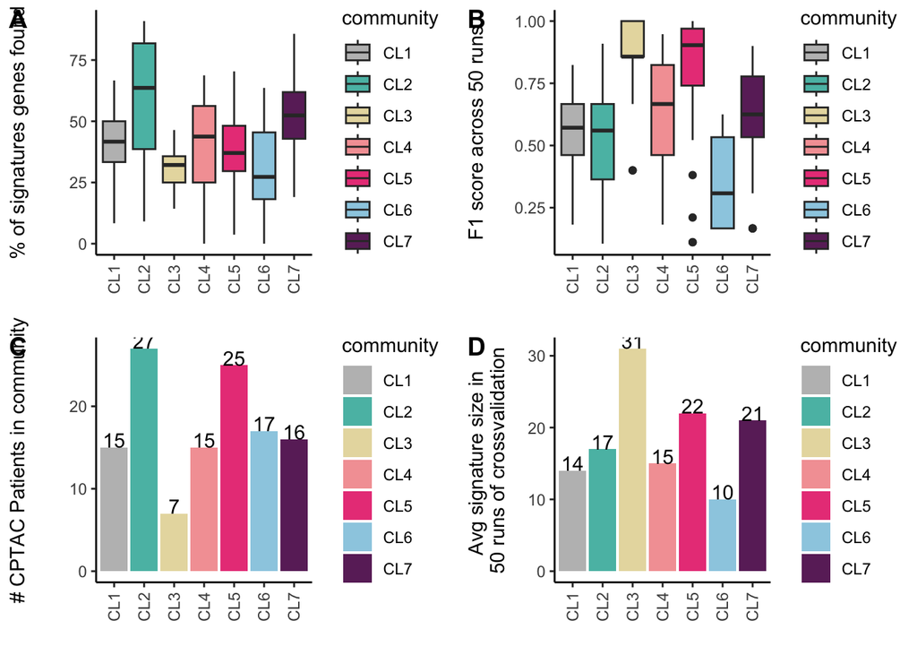

```r
plot_list_cross <- list(boxplot_intesection, boxplot_F1score, barplot_patients_comm, barplot_sign_size)

cowplot::plot_grid(plotlist = plot_list_cross, ncol = 2,
                   align = 'hv',
                   labels = LETTERS[1:4])
```

```r
# ggsave('../Figures/crossvalidation_cowplot.pdf', crossvalidation,
#        width = 8, height = 6, dpi = 300, device = 'pdf')
```

**Supplementary Figure. Cross-validation results for community-specific classification performance.** **A)** Percentage of signature genes recovered in each of 50 cross-validation runs per community. **B)** F1 score distributions showing classification performance across runs. **C)** Number of CPTAC patients assigned to each community in the full run. **D)** Average number of genes included in the signature for each community across the 50 cross-validation runs.